# Transport poverty: what it is, why it matters, and how to measure it

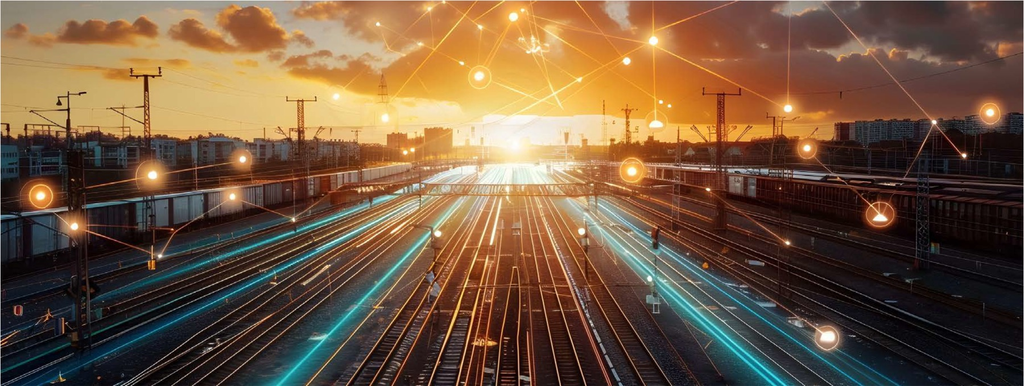

[figure not shown]

SUSTAINABLE  
MOBILITY FORUM

Transport poverty: what it is, why it matters, and how to measure it

Mauricio Orozco-Fontalvo

## Warm-up

In one word, what does **transport poverty** mean to you?

Join at **menti.com** with code **8417 4846**

Keep your word in mind. We will compare it with what 23 practitioners from Lisbon answered.

[interactive chart not shown]

# 1 · What is transport poverty?

One problem, many names

## One problem, many names

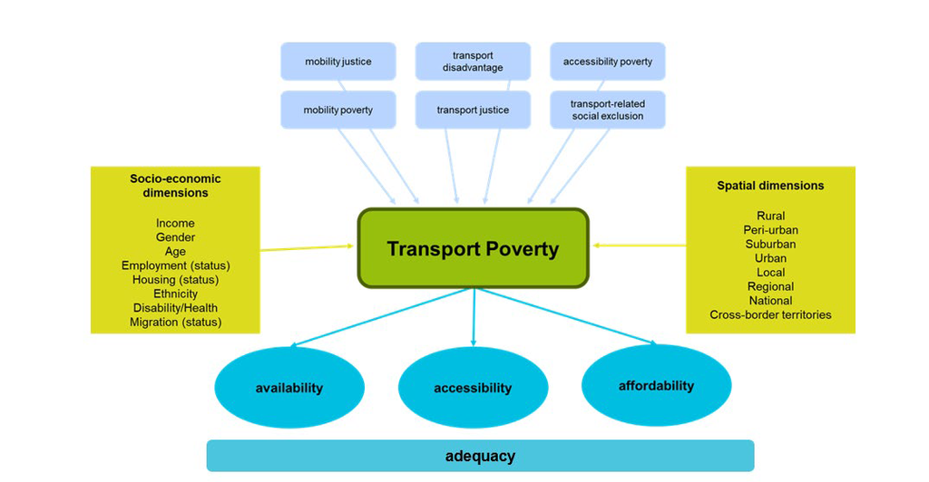

Transport poverty and its related terms, with socio-economic and spatial dimensions

- No single, universally accepted definition (Lucas et al. 2016; Mattioli et al. 2018)
- Narrow use: inability to **pay** for transport. Broad use: inequity in **access**

## A working definition

Transport poverty is the inability of an individual or household to **access essential services or opportunities** because transport is **limited or non-existent, inadequate, unreliable, unaffordable, time-consuming or unsafe**.

After Mejia-Dorantes and Murauskaite-Bull (2022), building on Lucas et al. (2016)

**In Europe it is also a legal concept.** Regulation (EU) 2023/955, which created the **Social Climate Fund**, gives the first binding EU definition: difficulty meeting transport costs, or limited access to the transport needed to reach essential services, taking the national and spatial context into account (European Parliament and the Council of the European Union 2023).

# 2 · The dimensions

What the definition asks us to look at

## Accessibility and mobility

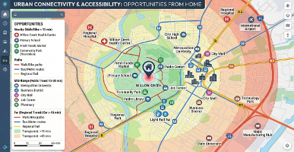

**Accessibility**Which places can I reach? Work, school, health care and services within a reasonable time (Geurs and Wee 2004).

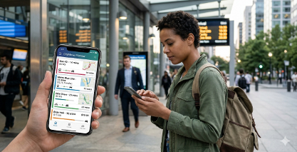

**Mobility**How easily can I reach them? Frequency, transfers, travel time and infrastructure of the transport system (Levinson and King 2020).

Two places can reach the same hospital in 30 minutes, one by a train every 5 minutes and one by a bus twice a day. **Accessibility alone cannot tell them apart.**

## Accessibility: reach within a time threshold

Accessibility counts the **opportunities that can be reached within a travel-time threshold**: for example, the health centres within 15, 30 or 45 minutes.

The result depends on **how long we are willing to travel** and on **which mode** we use. Walking reaches a small circle; the car reaches most of the city.

Distance-weighted (gravity) measures count nearer opportunities more, instead of using a hard threshold (Geurs and Wee 2004).

[interactive chart not shown]

Travel time

Destinations reachable:

Schematic illustration: dots are destinations such as health centres; speeds are illustrative.

## Mobility: how good is the service?

Mobility describes **the transport system itself**, beyond what can be reached (Lucas et al. 2016; Levinson and King 2020):

- **Travel time** on regular trips, such as the commute
- **Transfers** needed on public transport
- **Frequency** of service: peak, off-peak, night, weekend
- **Coverage**: who lives within walking distance of a stop
- **Infrastructure** for walking and cycling

**Why it is separate from accessibility**  
A destination can be within reach on paper, yet the trip may be slow, infrequent, unreliable or unsafe to walk to. Mobility captures that quality of supply.

**Computed per mode**  
A neighbourhood can be well served by a bus and poorly by a bicycle lane. Mobility is usually measured separately for each mode.

## Affordability and externalities

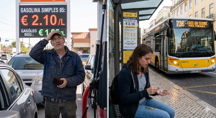

**Affordability**Can the household pay for the transport (and housing) it needs? Fuel, fares and the cost of living where transport is poor (Isalou et al. 2014; Litman 2026).

[figure not shown]

**Externalities**Who bears the harm of the transport system? Crashes, noise and air pollution fall unevenly across people and places (Lucas et al. 2016).

The European Commission names the dimensions *Availability* (≈ mobility), *Accessibility* and *Affordability*, with externalities folded into *Adequacy* (2024).

## Measuring affordability: spending rules

Affordability asks whether a household can pay for the transport (and housing) it needs. The classic answer borrows from fuel and energy poverty:

| Rule | Idea | Source |
| --- | --- | --- |
| **10% rule** | Spending more than 10% of income on transport | Adapted from fuel poverty (Alonso-Epelde et al. 2023) |
| **2M rule** | Spending more than twice the national median | Adapted from energy poverty (Alonso-Epelde et al. 2023) |
| **Housing + transport** | Combined cost above about 45% of income | (Isalou et al. 2014; Litman 2026) |

All three are **simple, cheap and comparable**. They need **household income and expenditure data**, usually from budget surveys.

## What spending rules miss

**Low spending can mean no access.** People who cannot afford or reach transport simply stop travelling, and expenditure rules count them as fine.

**High spending can mean choice.** Affluent car users are flagged even when they have good options.

**Cost is only one dimension.** Distance, service quality, travel time and safety never enter the calculation, which is why the other dimensions matter.

**No place, no mode.** Budget surveys say little about *where* the problem is or which mode could solve it.

## Externalities: who bears the harm?

Externalities are the **negative effects of the transport system**: road crashes, noise and air pollution. They are considered only in the broadest definitions of transport poverty and are commonly left out of composite indices (Lucas et al. 2016; Kelly et al. 2023).

- **Crash rates** per inhabitant
- **Severity** of crashes: fatalities among victims
- **Mode-specific** risk for pedestrians, cyclists and motorised users
- **Air quality and noise**, where open data exist

**The burden is unequal**  
Motorised users generate most externalities, but vulnerable road users bear a disproportionate share of the health, space and time costs (Gössling 2016).

**Not a matter of income only**  
Exposure depends on where people live and how they travel, so it cannot be inferred from cost or accessibility alone.

# 3 · Why does it matter?

Who is left out, and why now

## Transport is a gateway

When access is limited by **insufficient supply, high costs or high exposure to externalities**, people lose the ability to reach:

- work
- education
- health care
- services and food
- social life

The consequence is **social exclusion**, a state in which a person or group is left out of regular social activities (Pritchard et al. 2014; Unit 2003), and **socio-territorial inequality** (Hidayati et al. 2021).

## The burden is not shared equally

- **Risk.** Vulnerable road users bear a disproportionate share of the health, space and time costs, risk of exclusion or exposure. (Gössling 2016; Lucas et al. 2016)
- **Location.** Lower-income households cannot afford to live in central areas and are often pushed to places poorly served by public transport (Fedorowicz et al. 2020; Lopes et al. 2023)
- **Forced car ownership.** In weakly served peripheries the car becomes a necessity, and households carry a heavy cost burden even when travel is not expensive in absolute terms (Mattioli 2017; Mattioli et al. 2018)

> Transport poverty the combination of **accessibility, travel level of service, living conditions and exposure to undesired external effects**.

## Why it is on the policy agenda now

**European Pillar of Social Rights**

The principle of access to essential services is enshrined in it.

**Social Climate Fund**

Regulation (EU) 2023/955 created the fund and gives the first legally binding European definition of transport poverty (European Parliament and the Council of the European Union 2023).

**Local planning**

Sustainable Urban Mobility Plans (SUMPs) need to know *where* to act and *what* to fix.

Systematic quantification is still scarce, and the literature on composite indicators is limited (Primc et al. 2025). **That is the measurement problem of this lecture.**

# 4 · From dimensions to a measure

Composite indicators

## Four dimensions, one measure

Each dimension has its own indicators. To say **how transport poor a place is**, the four dimensions have to be combined.

That is what a **composite indicator** does: it aggregates several indicators into a single score (OECD et al. 2008).

Accessibility

Mobility

Affordability

Externalities

→

Transport poverty score

A single score **ranks places, targets funds and tracks change**. But it also hides things, and every step of the combination is a choice. Has it been done before?

## A single score, or many indicators?

> “multiple indicators are better than any single metric or composite” (Lowans et al. 2021)

**Risk of one number**  
A composite can hide which dimension is failing.

**Value of one number**  
It ranks places, targets funds and communicates quickly.

**A defensible answer:** publish the composite *together with* every dimension and indicator, so users can drill down.

## Composite indices: who covers which dimension?

| Study | Scale | Accessibility | Mobility | Affordability | Externalities |
| --- | --- | --- | --- | --- | --- |
| Kelly et al. (2023) | Ireland, small areas | ✓ | ✓ | ✓ | – |
| Primc et al. (2025) | EU-27, country | ✓ | ✓ | ✓ | ◐ |
| Aberle et al. (2025) | Berlin, Hamburg | ✓ | ◐ | – | – |
| Bocarejo S. and Oviedo H. (2012) | Bogotá, zones | ✓ | – | ✓ | – |
| Allen and Farber (2019) | Canada, 8 cities | ✓ | – | – | – |
| Alonso-Epelde et al. (2023) | Spain, households | ◐ | – | ✓ | – |
| Dalla Longa et al. (2025) | Netherlands, households | – | – | ✓ | – |

✓ covered · ◐ partial (extended variant, one indicator or PT service quality only) · – not covered. Adapted from the review in the IMPT paper.

**Pattern:** most cover one to three dimensions, many rely on surveys or data on request, and few reach the neighbourhood scale.

# 5 · What stands in the way

Data

## Data is the bottleneck

- **Mobility surveys** are expensive and rarely run on a regular cycle, so continuous monitoring is hard (Instituto Nacional de Estatística 2018; Pritchard et al. 2014)
- **Data on request** (microdata, registries) ties each study to its authors and limits replication (Kelly et al. 2023; Alonso-Epelde et al. 2023)
- **Primary data**, such as interviews, cannot be updated periodically (Aberle et al. 2025)
- **Scale** ranges from country (Primc et al. 2025) to city (Aberle et al. 2025), too coarse for local intervention
- **Data gaps** across mobility, affordability and externalities (Verhorst et al. 2023; Alonso-Epelde et al. 2023; Imprialou and Quddus 2019)

## Each dimension has its own data problem

| Dimension | Typical sources | Typical problem |
| --- | --- | --- |
| Accessibility | Road network (OpenStreetMap), public transport timetables (GTFS), points of interest | Needs routing engines and clean, geocoded destinations |
| Mobility | GTFS frequencies, census commuting, infrastructure maps | Operators publish in different formats; quality varies |
| Affordability | Census income, housing costs, fares | Household-level income and spending are not available at fine scale |
| Externalities | Crash records, air quality, noise maps | Open data fine enough for small areas is rare, especially for air and noise |

Two further dimensions **can be considered**, data permitting: **digital literacy** and **perceived accessibility** (Durand et al. 2022; Farber 2025).

## Where you draw the boundary changes the answer

- Parishes
- Municipalities
- Grid cells

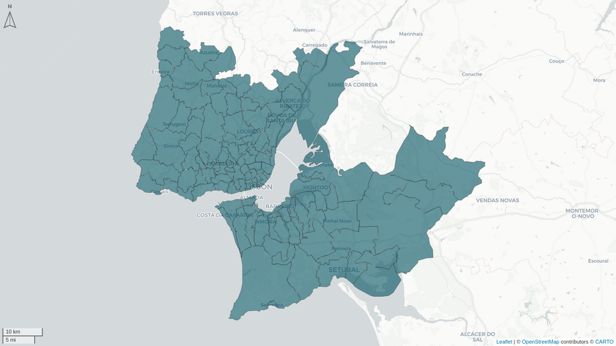

Parishes: 124 units

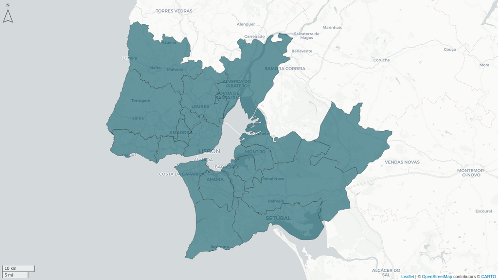

Municipalities: 18 units

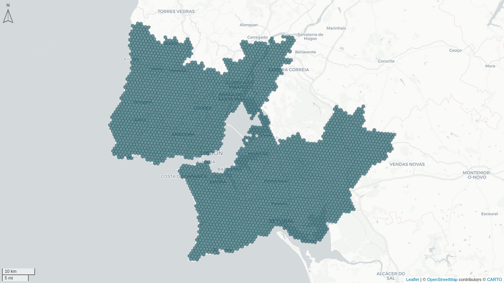

The same territory at three spatial resolutions. Averages over large units hide pockets of disadvantage.

## Where do people actually live inside a unit?

[figure not shown]

Census block data are coarse

[figure not shown]

Resident population redistributed using buildings

Averages over a parish can mislead when people live in a small part of it. Distributing the population across **buildings** gives better accessibility and safety indicators.

# 6 · Our proposal: the IMPT

How it is built and what it shows

## Our proposal: the IMPT

Looking back at the composite indices, **none combined** all four dimensions, several modes and a fine spatial scale using open data.

The **Multidimensional Transport Poverty Index (IMPT)** was designed to do so.

- **4 dimensions**: accessibility, mobility, affordability, safety
- **4 modes**: car, public transport, walking, cycling
- **Open data and open code**, so it can be recomputed
- Results at **parish, municipality and grid** level
- Composite score **and** every dimension and indicator visible

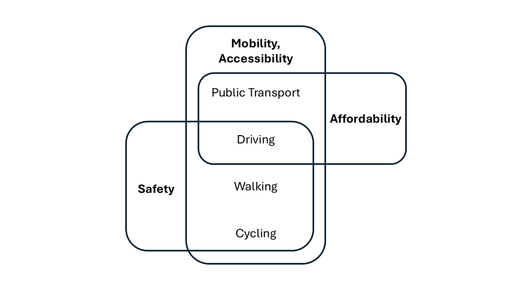

Modes considered per dimension

## Case study and open data

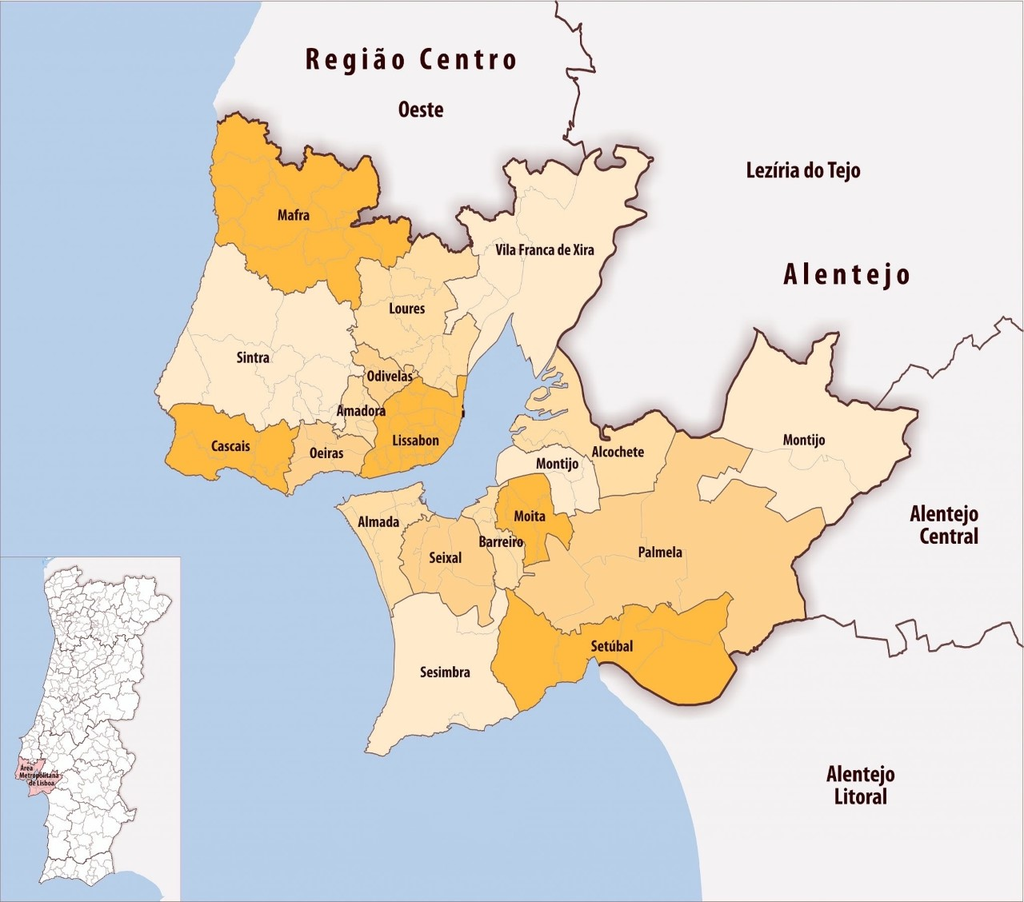

Lisbon Metropolitan Area

18 municipalities, 124 parishes, about 2.8 million inhabitants, 3,000 km². The parish is the unit of analysis.

| Source | Used for |
| --- | --- |
| Census 2021 and mobility survey (INE) | Income, housing, commuting, modal share |
| OpenStreetMap | Road network, walking and cycling infrastructure, points of interest |
| GTFS timetables (9 operators) | Frequency, travel times, coverage |
| Road-safety authority records | Crash locations and severity, 2019–2023 |

## How the IMPT is built

**1 Indicators**For each dimension and each mode

→

**2 Open data**Census, OpenStreetMap, timetables, crash records

→

**3 Normalise**Every indicator on a 0–100 scale

→

**4 PCA**One score per dimension

→

**5 Aggregate**Four dimensions into one index

→

**6 Validate**Workshop with municipalities

Following the OECD/JRC Handbook on composite indicators (OECD et al. 2008). The next slides go through each step, starting with the indicators.

## Accessibility in the IMPT

The IMPT counts the destinations reachable within time thresholds, for every mode, using the open routing tool `r5r` (Pereira et al. 2021; Pereira and Herszenhut 2023).

- Walking
- Cycling
- Public transport
- Car

[figure not shown]

Health centres reachable on foot

[figure not shown]

Health centres reachable by bicycle

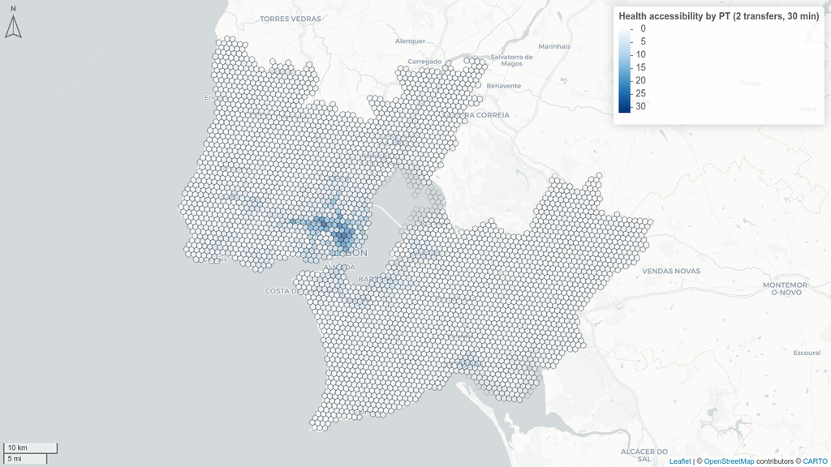

Health centres reachable by public transport

[figure not shown]

Health centres reachable by car

Same destinations, four modes: **a place can be rich in access by car and poor without one.**

## Mobility and affordability in the IMPT

#### Mobility

- Average commuting time by mode
- Number of transfers on public transport
- Frequency (peak, off-peak, night, weekend)
- Population within walking distance of stops
- Walking and cycling infrastructure

#### Affordability

- Housing **plus** transport cost as a share of income, kept **continuous** instead of a pass/fail line
- Car cost per kilometre including tolls
- Public transport fares and passes

[figure not shown]

Transport plus housing burden (%)

## How the IMPT normalises indicators

Indicators come in different units (minutes, euros, crashes per 1,000 people) and different directions (more is better, or worse).

The IMPT normalises each one to a 0–100 scale and aligns the direction, so that a higher score always means a better situation.

$$X_{norm} = \frac{X - X_{min}}{X_{max} - X_{min}} \times 100 \qquad\text{or}\qquad X_{norm} = \frac{X_{max} - X}{X_{max} - X_{min}} \times 100$$

The first form is for indicators where more is better (jobs reachable), the second for indicators where more is worse (travel time, cost).

## What is PCA?

**The problem.** A dimension is described by many indicators, and many of them move together (for example, jobs reachable in 30 and in 45 minutes). Adding them up counts the same information twice.

**The idea.** Principal component analysis (PCA) finds the direction along which places differ **most**. The first component (PC1) is that direction. Each place gets one score: its position along it.

**What you get.** One score per dimension, with weights taken from the data instead of the analyst’s choice. PCA is the approach recommended by the **OECD/JRC Handbook** on composite indicators (OECD et al. 2008).

[interactive chart not shown]

Rotate the axis

Variation kept by this axis:

Each dot is a parish (accessibility and mobility scores, standardised). The dots stay fixed: the axis rotates, and each parish gets a score where it lands on the axis. Illustration only.

Check: PC1 should capture a large share of the variation, and every indicator should push it in the same direction.

## How the IMPT combines indicators

1. **Normalise** every indicator to 0–100, higher meaning better.
2. **Within each dimension**, PCA gives one score (PC1), following the OECD/JRC Handbook (OECD et al. 2008). With too few indicators, a simple composite is used.
3. **Across dimensions**, four ways of aggregating answer four different questions.

| IMPT variant | Formula | It answers |
| --- | --- | --- |
| Critical | $\displaystyle \Big(\prod_{d}(S_d+1)\Big)^{1/D}-1$ | Is any dimension severely deficient? |
| Balanced | $\displaystyle \frac{1}{D}\sum_{d} S_d$ | How does a place do on average? |
| Contrasting | $\displaystyle \prod_{d}(S_d+1)^{w_d}-1$, entropy weights | Where do places differ most? |
| Political | User-set weights (AHP) | What do decision-makers value? |

Published values are reversed ($100 - v$), so that higher means more transport poverty.

## Entropy weights: a worked example

**Idea.** A dimension on which every place scores the same cannot tell places apart, so it should count less. Entropy measures that.

1. Share of place $i$: $p_i = S_i / \sum S$
2. Entropy: $e = -\dfrac{1}{\ln m}\sum p_i \ln p_i$, between 0 and 1. Close to 1 means all places look alike
3. Weight: $w_d = \dfrac{1-e_d}{\sum_k (1-e_k)}$

| Place | Dimension X | Dimension Y |
| --- | --- | --- |
| 1 | 50 | 10 |
| 2 | 70 | 90 |
| 3 | 40 | 30 |
| 4 | 80 | 95 |
| 5 | 60 | 20 |
| **Entropy $e$** | 0.98 | 0.83 |
| **$1-e$** | 0.018 | 0.175 |
| **Weight $w$** | **0.09** | **0.91** |

X is similar everywhere, so it gets 9% of the weight. Y separates places strongly and gets 91%. For place 1 the equal-weight geometric mean gives 77.3 (poverty scale), the entropy-weighted one 88.4, because its weak Y now counts for more.

## Relative scores have limits

- Min–max scaling makes an index **relative**: a score tells you how a place compares with the others
- Re-computing it for a later year **re-normalises** everything, so a parish can move because *others* changed
- Scores from different metropolitan areas are **not directly comparable** without common benchmarks

> Always ask of any index: **relative to what?**

## Who decides the weights?

Rank the four dimensions by how much they should count in a place you know well

- Accessibility
- Mobility
- Affordability
- Safety

Type your answer in the chat

The result is the weighting you would give the index. Different answers are not errors: they are different **value judgements**.

## The four dimensions in Lisbon

- Accessibility
- Mobility
- Affordability
- Safety

[figure not shown]

- High in the centre
- Deficits in **rural, low-density** parishes

[figure not shown]

- Reflects the **radial** structure of the region
- The periphery is much harder to travel from

[figure not shown]

- Mostly good scores; the monthly pass helps
- Worst in **lower-income, car-dependent** areas

[figure not shown]

## One index, three readings

- Contrasting
- Critical
- Balanced

[figure not shown]

Entropy weights: best for comparing territories

[figure not shown]

Geometric mean: penalises the weakest dimension

[figure not shown]

Arithmetic mean: lets dimensions compensate

Higher score = higher transport **poverty**. The most affected parishes are in the car-dependent periphery; the least affected are in central Lisbon.

## The IMPT dashboard

**ushift.tecnico.ulisboa.pt/apps/impt**

- Maps at parish, municipality and grid level
- Every dimension, mode and indicator
- **Political IMPT**: set your own weights (AHP)
- Downloadable results

[Open the dashboard](https://ushift.tecnico.ulisboa.pt/apps/impt)

[figure not shown]

[figure not shown]

Scan to open

## Does it match local knowledge? A workshop

[figure not shown]

Workshop with municipal technicians and transport stakeholders, Lisbon, April 2026

- All 18 municipalities invited, **23 participants**
- Each scored up to three parishes of their own municipality on the global index and each dimension (0–100)
- **36 parishes** scored; perception compared with the model

**Agreement:** moderate for global score, accessibility and mobility (rank correlations about 0.43–0.55), weaker for affordability (about 0.30).

## What the workshop showed

- Global IMPT
- Accessibility
- Mobility
- Affordability
- Safety

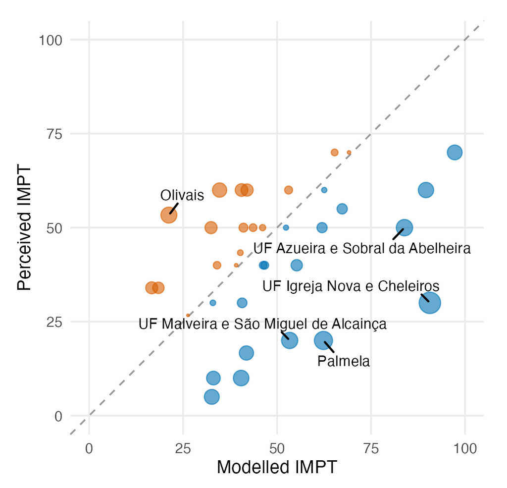

Moderate agreement for the global index (rank correlation about 0.43 to 0.55).

About half of the parishes were within 15 points of the modelled score.

Peripheral car-dependent parishes were rated less transport poor than the model; dense inner parishes such as Olivais were rated more.

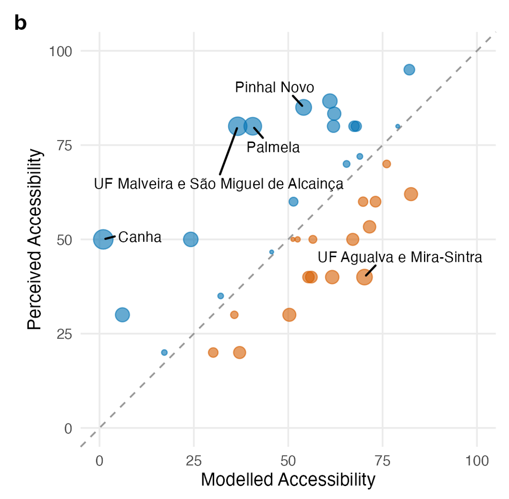

Moderate agreement, similar to the global index.

Rural parishes such as Canha were rated better than the model suggests.

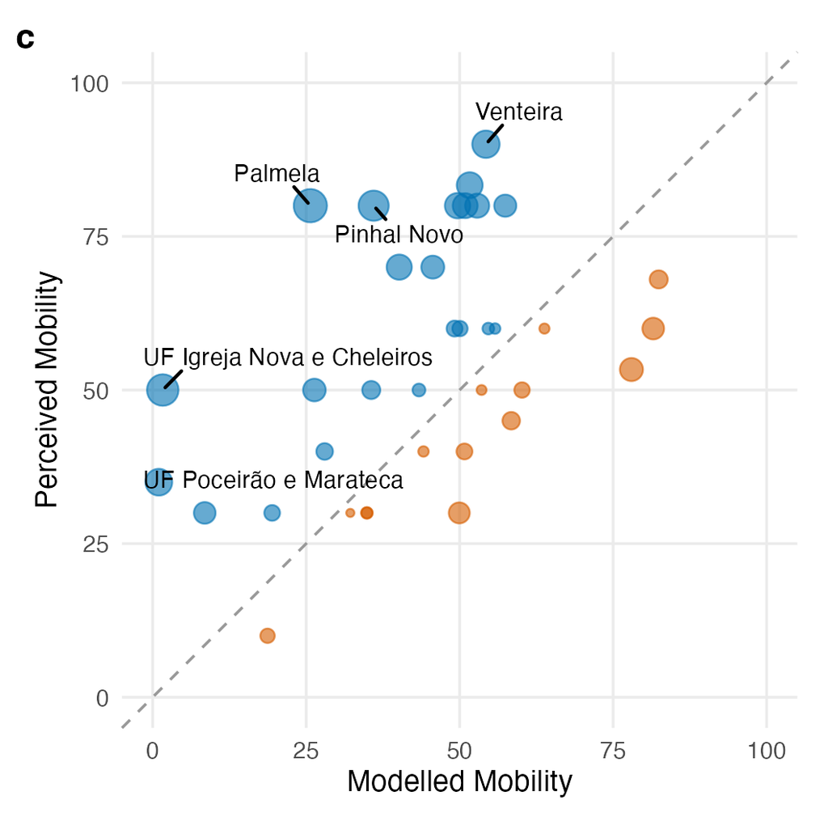

Moderate agreement as well.